# **IMAE-Valle**

# **Algunas librerias**

```
## Successfully loaded changepoint package version 2.2.3
##  See NEWS for details of changes.
```

Los datos de series temporales pueden exhibir una variedad de patrones y, frecentemente, es útil dividir una serie temporal en varios componentes, cada uno de los cuales representa una categoría de patrón subyacente.

# **Datos IMAE**

https://www2.javerianacali.edu.co/facultades/ciencias-economicas-y-administrativas/imae#gsc.tab=0

```
##        Jan   Feb   Mar   Apr   May   Jun   Jul   Aug   Sep   Oct   Nov   Dec
## 2002   2.0   2.3   2.8   2.5   3.6   4.5   3.4   2.2   1.9   3.6   3.5   3.9
## 2003   3.1   3.3   3.2   3.2   3.0   1.5   3.3   3.4   4.3   4.1   5.0   3.8
## 2004   5.1   5.2   5.9   4.7   5.0   6.0   5.3   5.0   3.9   3.7   3.5   3.8
## 2005   2.7   2.9   1.9   2.9   0.8   1.6   0.6   2.2   2.7   1.8   1.0   3.5
## 2006   4.7   4.4   5.3   6.3   8.7   8.3  11.1  10.4  11.9  12.7  12.8   9.9
## 2007   9.5  10.3  11.0   9.3   8.6   9.2   7.0   6.8   6.8   6.0   7.3   7.1
## 2008   6.1   5.1   3.4   4.3   2.5   2.5   3.1   1.9   0.7   0.5  -2.2  -0.7
## 2009  -0.2   0.3   0.2   0.5   1.6  -0.7   0.5   0.1   0.1   1.2   3.2   2.1
## 2010   1.6   1.0   2.4   0.3   1.7   2.6   0.0   2.3   2.1   2.4   1.2   1.2
## 2011   2.8   3.1   3.1   4.5   4.4   4.2   5.4   5.6   4.7   4.5   5.7   5.9
## 2012   4.9   5.3   5.2   4.7   3.4   5.4   4.4   1.7   3.9   2.2   2.6   2.2
## 2013   3.0   2.1   1.9   3.9   3.7   3.7   5.1   5.3   5.0   6.7   5.8   6.6
## 2014   5.6   7.1   6.4   5.9   5.5   3.7   4.2   5.2   4.7   4.7   4.3   3.8
## 2015   3.8   3.1   4.1   2.1   3.1   3.3   3.1   3.2   2.5   1.9   1.7   2.6
## 2016   3.1   3.3   1.4   2.4   2.1   2.5   0.7   2.8   2.8   2.6   3.4   2.8
## 2017   1.7   0.8   0.9   2.2   1.1   2.7   3.6   1.2   1.3   1.6   1.5   2.7
## 2018   2.2   2.4   4.4   3.7   3.9   2.3   2.4   3.3   3.7   3.7   4.3   2.1
## 2019   3.5   4.1   4.6   1.6   4.2   3.8   4.4   3.9   3.1   3.3   2.3   3.4
## 2020   3.6   4.0  -8.6 -22.0 -15.9 -10.9  -8.8  -8.1  -5.3  -3.6  -2.4  -3.4
```

Graficamos la serie (esto ya estaba antes y con versiones más bonitas…esta no tiene formato)

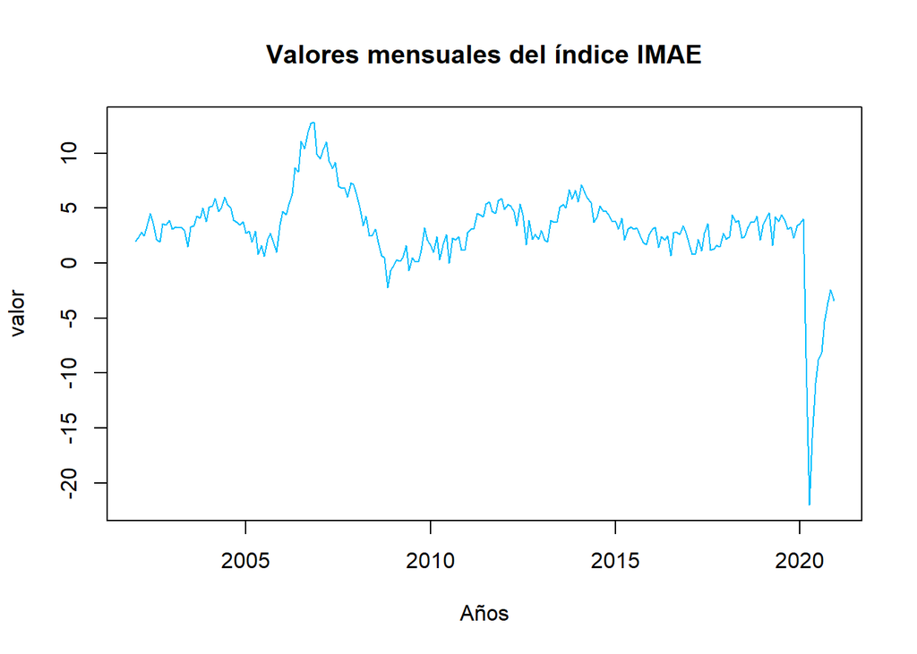

```
## [1] "ts"
```

```
## [1] 2002    1
```

```
## [1] 2020   12
```

Verificamos que sea ESTACIONARIA (Dicker-Fuller ‘adf.test’), si no lo es, entonces no podemos pronosticar más adelante usando modelos estacionarios.

```
##
##  Augmented Dickey-Fuller Test
##
## data:  Indice.ts
## Dickey-Fuller = -3.107, Lag order = 6, p-value = 0.1109
## alternative hypothesis: stationary
```

Recordemos que si el valor $p$ es menor que $0.05$ es estacionaria, en este caso NO es estacionaria. Pensando en un nivel de significancia del $5%$

De nuevo, verifiquemos el número de veces que debemos diferenciar para tener la estacionariedad

```
## [1] 1
```

Nos indica que $1$ así que diferenciamos una vez y renombramos a dif.Indice.ts

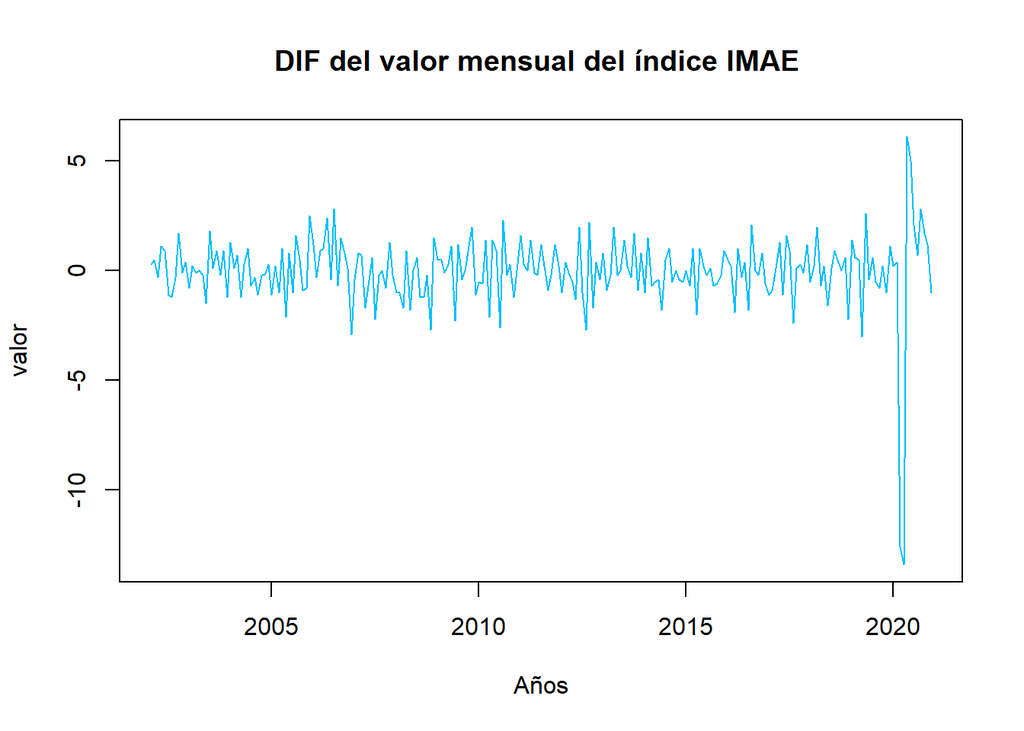

Volvemos a probar si es estacionaria

```
##
##  Augmented Dickey-Fuller Test
##
## data:  dif.Indice.ts
## Dickey-Fuller = -6.3716, Lag order = 6, p-value = 0.01
## alternative hypothesis: stationary
```

## **Funciones acf y pacf**

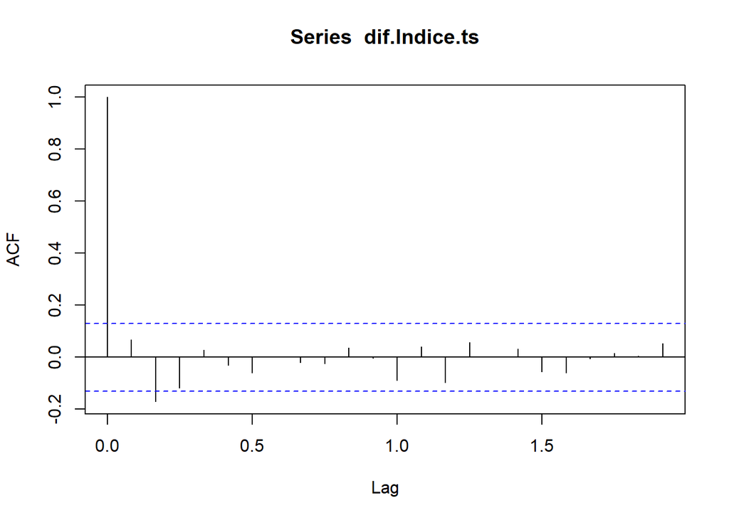

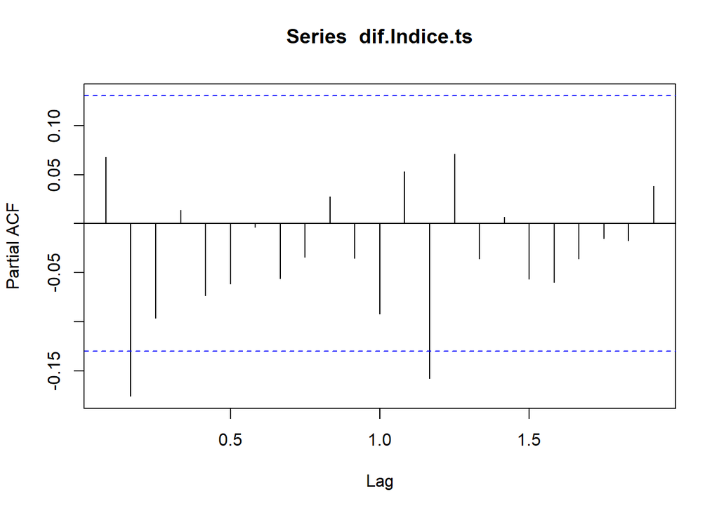

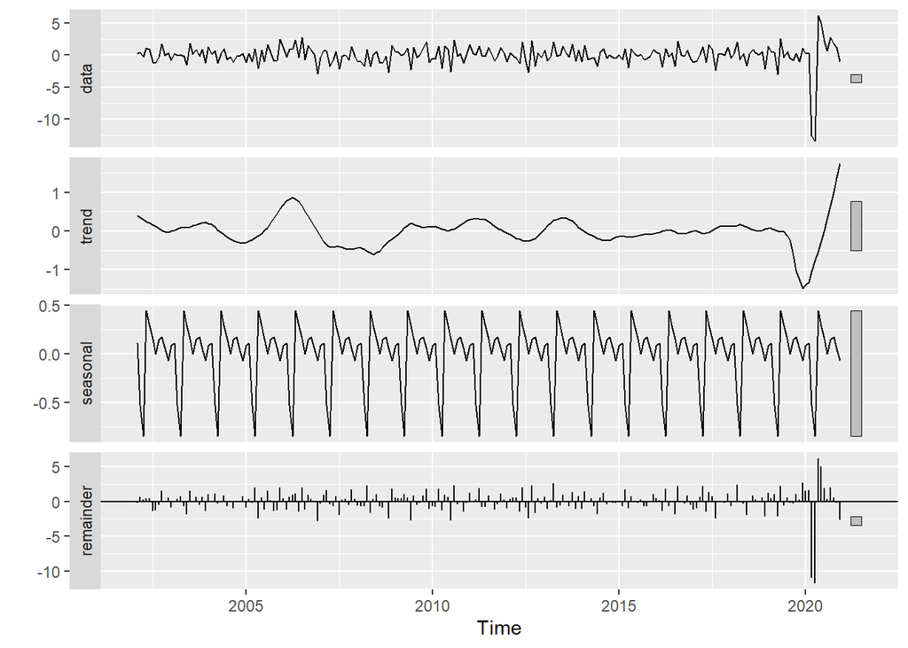

# **Modelo ¿ARIMA?**

Ahora, aplicamos la función auto.arima la cual nos encontraría un modelo de ajuste eficiente. En este caso, es ARIMA(0,0,3)(0,0,1)[12]

```
## Series: dif.Indice.ts
## ARIMA(0,0,3)(0,0,1)[12] with zero mean
##
## Coefficients:
##          ma1      ma2      ma3     sma1
##       0.0676  -0.2223  -0.1562  -0.6940
## s.e.  0.0655   0.0677   0.0720   0.1384
##
## sigma^2 = 2.651:  log likelihood = -434.78
## AIC=879.56   AICc=879.83   BIC=896.68
```

## **Observación 1**

Este es el modelo SARIMA, del cual hablaremos en la siguiente sesión. En este momento, no nos interesa el modelo sino que el metodo si detecte el cambio estructral.

## **Observación 2**

Atención en python

‘’from pyramid.arima import auto_arima model = auto_arima(…)’’

# **Punto de Cambio**

Ahora nos interesa detectar los puntos de cambio de la serie. En R hay varias funcione sen el paquete change.point. La función se llama cpt.mean y detecta un punto de cambio en la media

```
## [1] 219
```

### **Gráfica del punto de cambio**

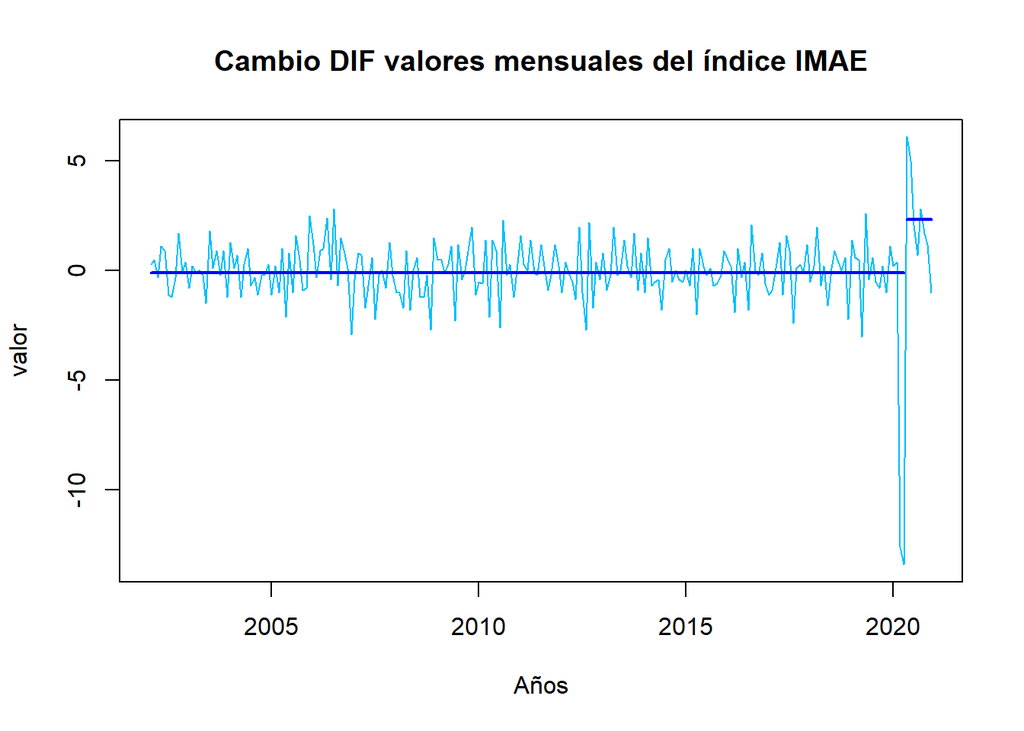

# **Predicción**

```
##          Point Forecast     Lo 80    Hi 80     Lo 95    Hi 95
## Jan 2021    -0.02387376 -2.269253 2.221506 -3.457885 3.410138
## Feb 2021    -0.02387376 -2.269253 2.221506 -3.457885 3.410138
## Mar 2021    -0.02387376 -2.269253 2.221506 -3.457885 3.410138
## Apr 2021    -0.02387376 -2.269253 2.221506 -3.457885 3.410138
## May 2021    -0.02387376 -2.269253 2.221506 -3.457885 3.410138
## Jun 2021    -0.02387376 -2.269253 2.221506 -3.457885 3.410138
```

# No todo los valores caen ya que hubo bloqueo, volvemos y lo hacemos con 3

```
##          Point Forecast     Lo 80    Hi 80     Lo 95    Hi 95
## Jan 2021    -0.02387376 -2.269253 2.221506 -3.457885 3.410138
## Feb 2021    -0.02387376 -2.269253 2.221506 -3.457885 3.410138
## Mar 2021    -0.02387376 -2.269253 2.221506 -3.457885 3.410138
```

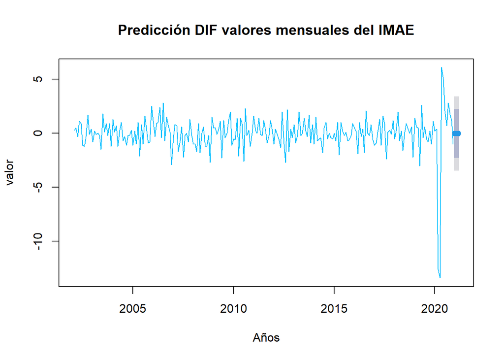

## **Observacion 3**: recuerde que este es el valor predicho de la diferencia

# **Validación**

Con esta otra libreria, se pude hacer validación, por ejemplo, detección de outliers.

```
## Series: dat.ts
## Regression with ARIMA(1,0,2) errors
##
## Coefficients:
##          ar1      ma1     ma2    TC217     AO219   TC220
##       0.7801  -1.3072  0.5106  -5.6343  -13.9188  7.9061
## s.e.  0.0836   0.1087  0.0883   0.7623    1.3628  0.6138
##
## sigma^2 = 1.446:  log likelihood = -361.15
## AIC=736.31   AICc=736.82   BIC=760.28
##
## Outliers:
##   type ind time coefhat   tstat
## 1   TC 217  217  -5.634  -7.391
## 2   AO 219  219 -13.919 -10.213
## 3   TC 220  220   7.906  12.881
```

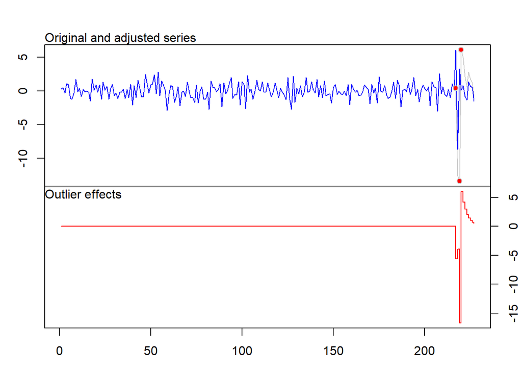

# **Supuestos de una ARIMA**

Aunque en este caso, sabemos que el modelo no es un ARIMA, vamos a suponer que lo es y verifiquemos los supuestos

## **Media cero de los residuos**

Primero vamos a ver si la media de los residuos es cero, aplicamos la prueba $t.test$ para evaluar

```
##
##  One Sample t-test
##
## data:  mr
## t = -0.38793, df = 226, p-value = 0.6984
## alternative hypothesis: true mean is not equal to 0
## 95 percent confidence interval:
##  -0.2530990  0.1698374
## sample estimates:
##  mean of x
## -0.0416308
```

Como el valor-P es 0.6984 y mayor que el nivel de significancia 5%, no se rechaza la hipótesis nula, es decir, que la media de los residuos es cero.

## **Independencia de los residuos**

Segundo vamos a evaluar la independencia de los residuos

```
## [1] 0.9622681
```

Como valor $p$ no es menor que $alpha4, no se rechaza $H_0$, osea que son independienets los residuos

### **¿Distribución?**

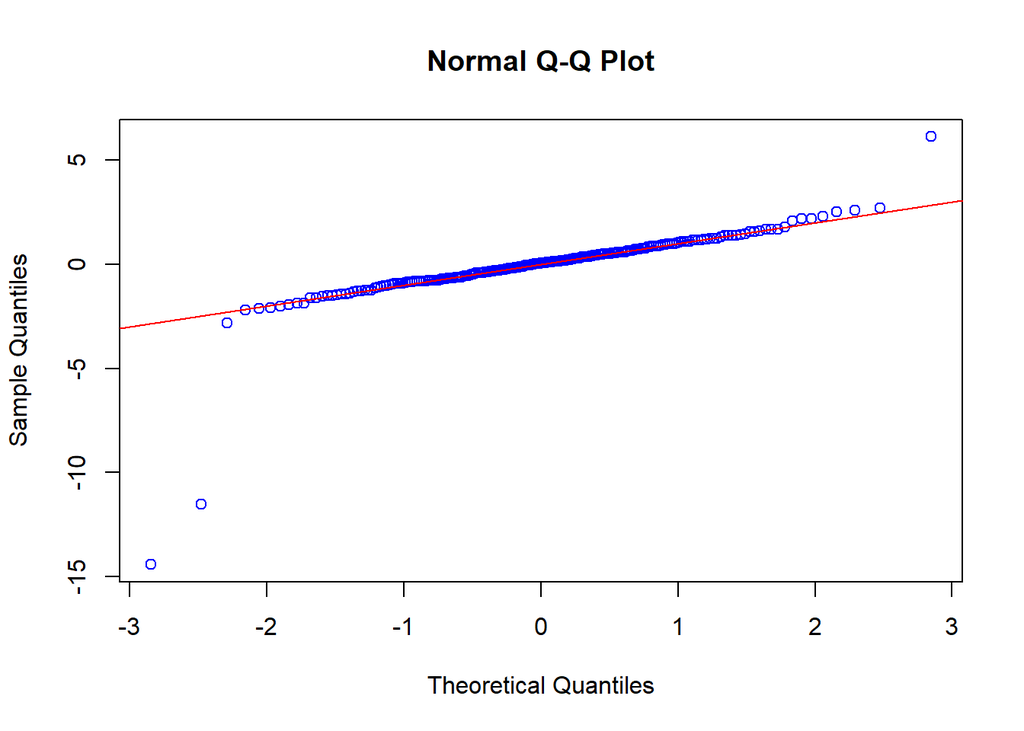

así que sigue mirar a través de una prueba, shapiro y tampoco es normal pero esa no es una condición absolutamente necesaria.

En esta primera prueba vemos que el componente estocástico (los residuos) no está normalmente distribuido por lo que se rechaza la hipótesis nula ya que el valor P es de: 2.2e-16

```
##
##  Shapiro-Wilk normality test
##
## data:  mr
## W = 0.66065, p-value < 2.2e-16
```

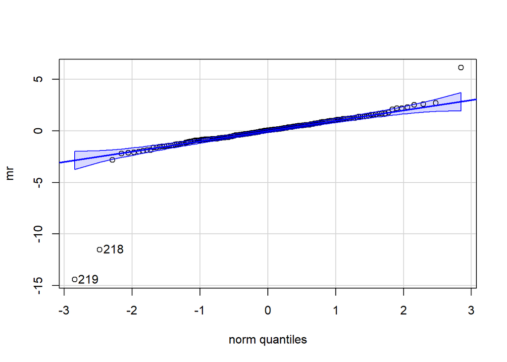

```
## [1] 219 218
```

Se busca cual es la distribución de ajuste y se intenta la t-distribution ya que es la más parecida visualmente

```
## NOTE: Packages 'fBasics', 'timeDate', and 'timeSeries' are no longer
## attached to the search() path when 'fGarch' is attached.
##
## If needed attach them yourself in your R script by e.g.,
##         require("timeSeries")
```

```
##      Min.   1st Qu.    Median      Mean   3rd Qu.      Max.
## -14.41482  -0.67135   0.05444  -0.04163   0.67900   6.12773
```

```
## [1] -4.381152
```

```
## [1] 40.35893
```

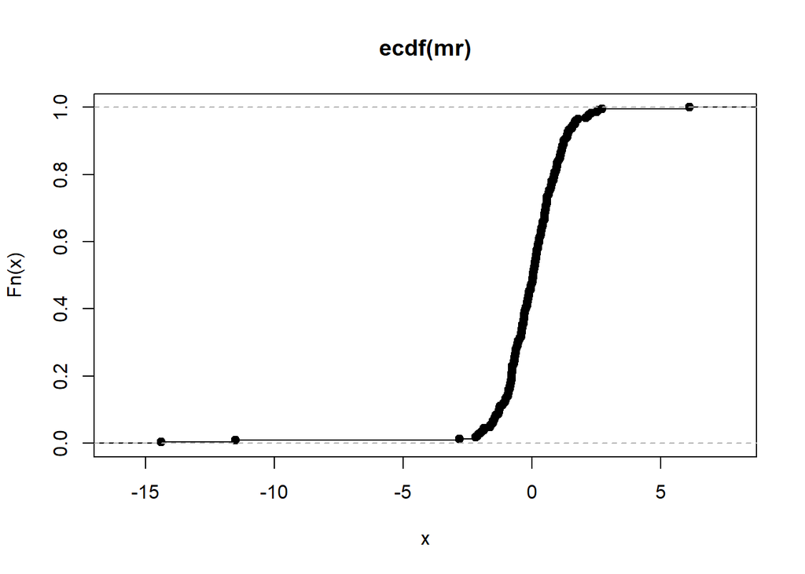

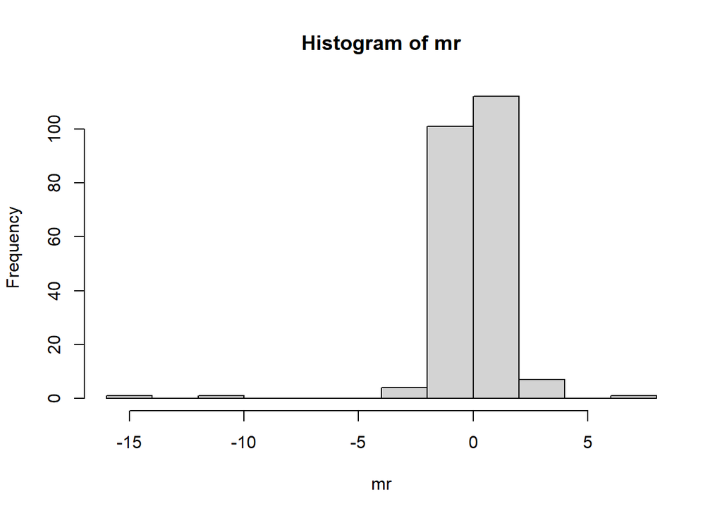

```
## $par
##      mean        sd        nu
## 0.0383951 1.2707413 3.4235422
##
## $objective
## [1] 347.0257
##
## $convergence
## [1] 0
##
## $iterations
## [1] 24
##
## $evaluations
## function gradient
##       33       94
##
## $message
## [1] "relative convergence (4)"
```

```
## [1] 227
```

y ahora vuelve y se genera una funcion de distribucion empirica que sirve para ver si se se ajuta la t-student

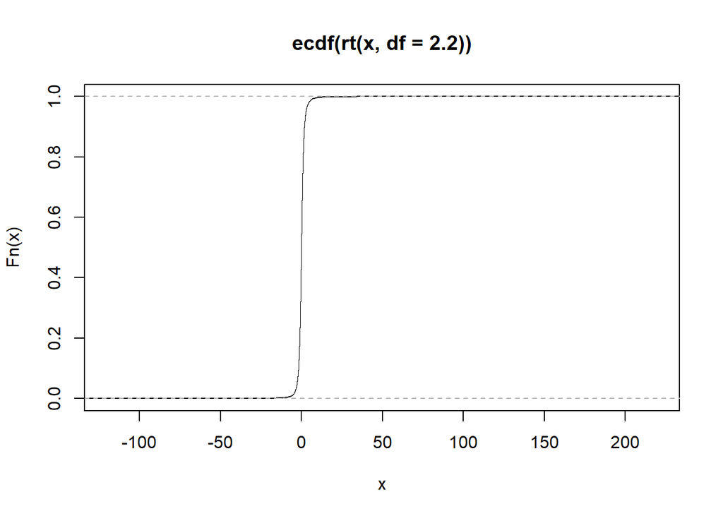